# Supervised Learning and Visualisation

Practical 5

Willem van Veluw

19-9-2022

For this practical we first load the necessary packages.

```r
library(tidyverse)
library(magrittr)
library(ISLR)
library(MASS)
library(class)
```

Next, we set the seed, import the data and classify everything as supposed to. Hence, the variables `PClass`, `Sex` and `Survived` are declared as factors.

```r
set.seed(45)
```

### Exercise 1

From the plot we can see that most default persons are the ones with a high balance. For instance, the mean balance of the entire dataset equals 835: there are only 3 default persons with a balance below this mean, as opposed to 5087 non-default persons.

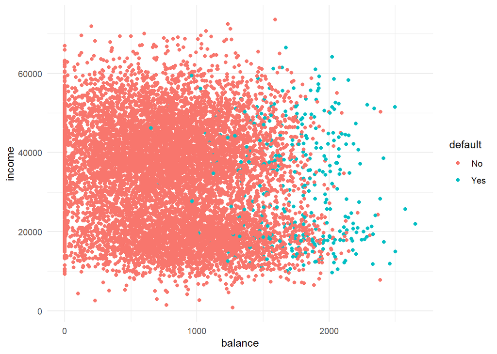

```r
scatter_default <- Default %>%
  ggplot(aes(x = balance, y = income, colour = default)) +
  geom_point() +
  theme_minimal()

scatter_default
```

### Exercise 2

The plot is quite interesting to see, as it becomes clear that students have a lower income than non-students. However, the pattern that we saw in exercise 1 still appears: default persons are thought to have a higher balance.

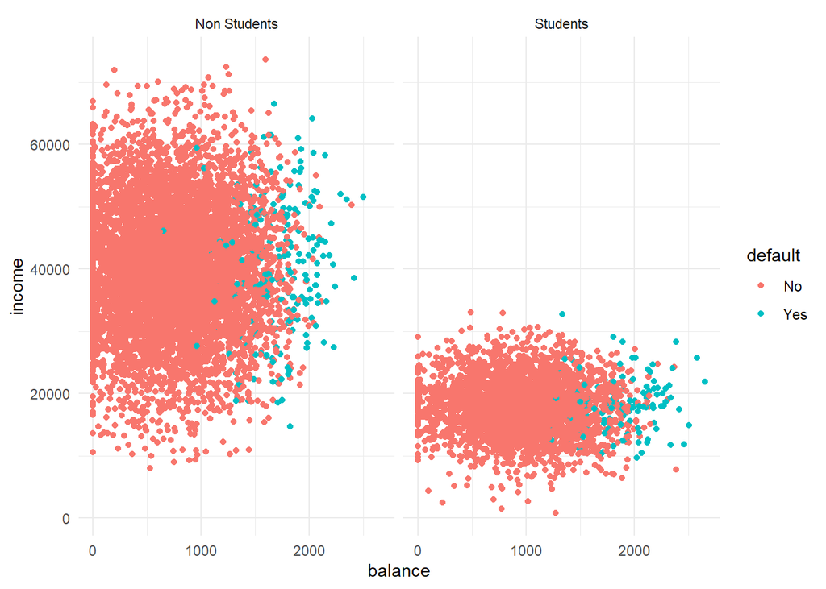

```r
facet_labs <- c(No = "Non Students", Yes = "Students")
scatter_default + facet_grid(col = vars(student),
                             labeller = labeller(student = facet_labs))
```

### Exercise 3

Note that the dataset is splitted randomly by the use of the function `sample()`.

```r
default_df <-
  Default %>%
  mutate(student = factor(ifelse(student == "Yes", 1, 0))) %>%
  mutate(split = sample(rep(c("train", "test"), times = c(8000, 2000))))

default_train <-
  default_df %>%
  filter(split == "train") %>%
  dplyr::select(-split)

default_test <-
  default_df %>%
  filter(split == "test") %>%
  dplyr::select(-split)
```

### Exercise 4

```r
knn_5_pred <- knn(train = default_train %>% dplyr::select(-default),
                  test = default_test %>% dplyr::select(-default),
                  cl = as_factor(default_train$default),
                  k = 5)
```

### Exercise 5

We see that the knn predicts less observations to be default. This can be derived from the fact that there are less blue dots in the graph with predictions.

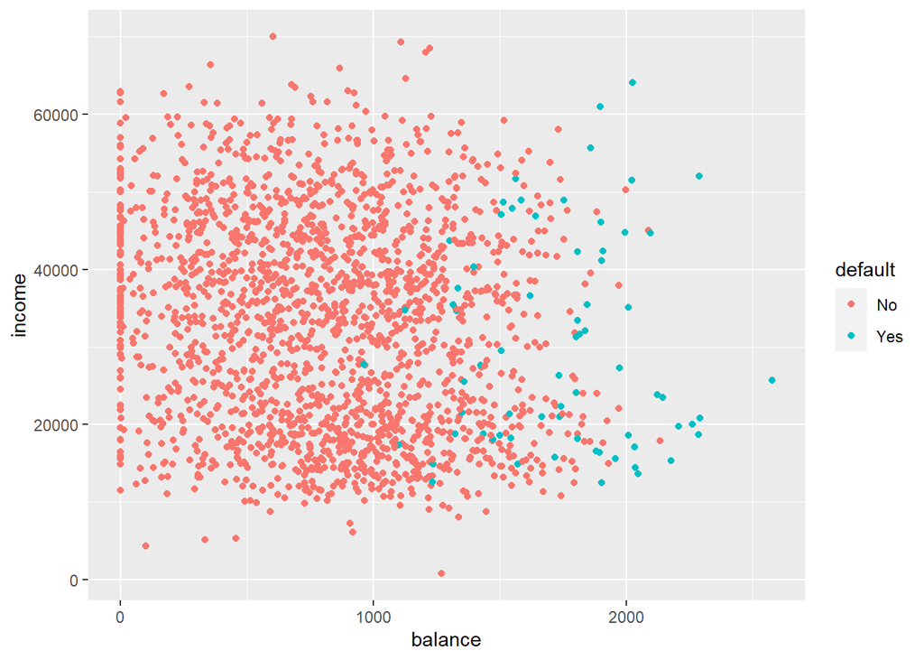

```r
default_test$prediction <- knn_5_pred

default_test %>% ggplot(aes(x = balance, y = income, colour = default)) + geom_point()
```

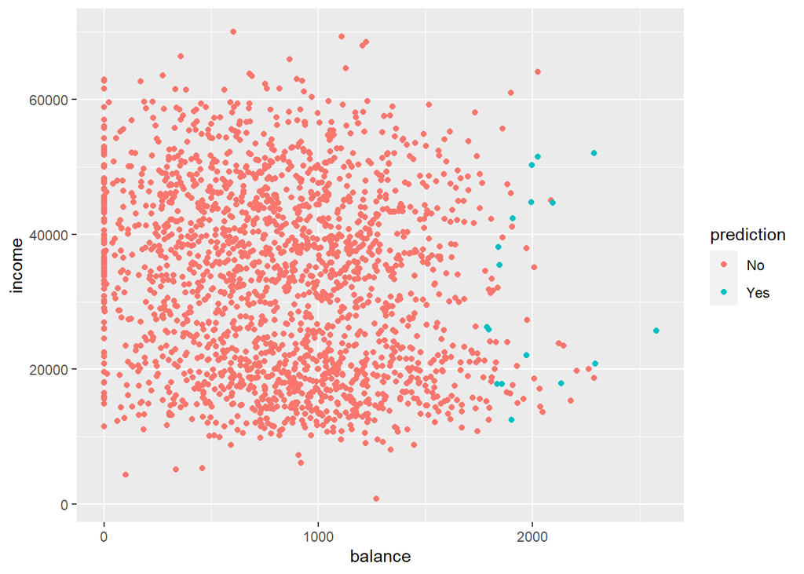

```r
default_test %>% ggplot(aes(x = balance, y = income, colour = prediction)) + geom_point()
```

### Exercise 6

Yes, there are differences. The knn with `k=2` predicts more observations to be default. However, there are clearly still some misclassified observations.

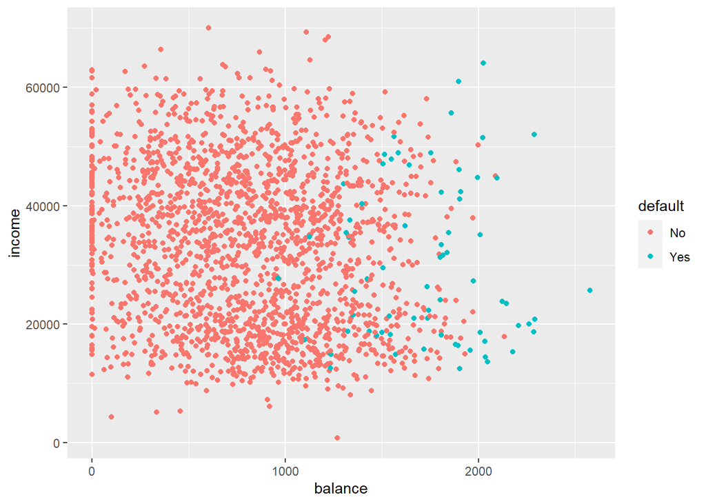

```r
knn_2_pred <- knn(train = default_train %>% dplyr::select(-default),
                  test = default_test %>% dplyr::select(-default, -prediction),
                  cl = as_factor(default_train$default),
                  k = 2)

default_test$prediction <- knn_2_pred

default_test %>% ggplot(aes(x = balance, y = income, colour = default)) + geom_point()
```

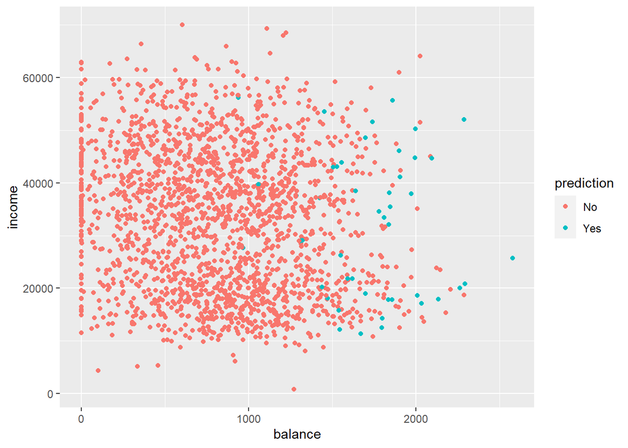

```r
default_test %>% ggplot(aes(x = balance, y = income, colour = prediction)) + geom_point()
```

### Exercise 7

If the classification were perfect, there would only be values on the diagonal of the confusion matrix. All other cells would be equal to zero.

### Exercise 8

```r
table(true = default_test$default, predicted = knn_5_pred)
```

```
##      predicted
## true    No  Yes
##   No  1922    8
##   Yes   61    9
```

### Exercise 9

```r
lr_mod <- glm(default ~ .,
              data = default_train,
              family = binomial)
```

### Exercise 10

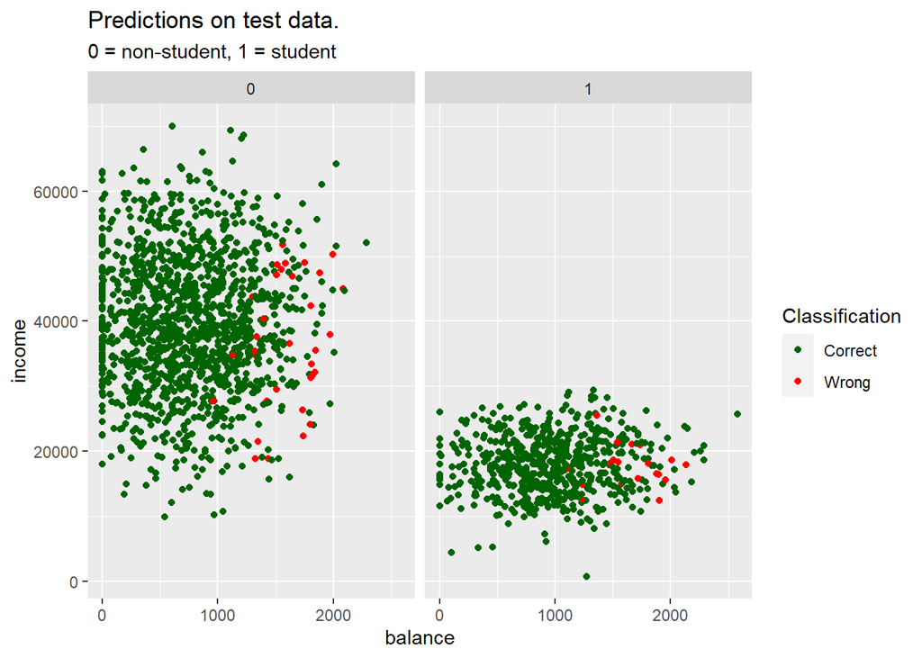

```r
lr_preds <- predict(lr_mod, newdata = default_test, type = "response")
default_test <- default_test %>%
  mutate(probs = lr_preds,
  prediction = ifelse(probs >= 0.5, "Yes", "No"),
  perform = ifelse(default == prediction, "Correct", "Wrong"))

default_test %>% ggplot(aes(x = balance, y = income, colour = perform)) +
  geom_point() +
  scale_color_manual(values = c("darkgreen", "red")) +
  facet_grid(col = vars(student)) +
  labs(title = "Predictions on test data.",
       subtitle = "0 = non-student, 1 = student",
       colour = "Classification")
```

```r
table(true = default_test$default, pred = default_test$prediction)
```

```
##      pred
## true    No  Yes
##   No  1925    5
##   Yes   47   23
```

### Exercise 11

For a non-student with an income of 40000 and balance of 3000, the probability of default equals
$$\begin{align}
P(default | student, income = 40000, balance = 3000) & = logit^{-1}(\beta_0+4000\cdot\beta_2+3000\cdot\beta_4) \\
&\approx 0.9982.
\end{align}$$

```r
lr_mod
```

```
##
## Call:  glm(formula = default ~ ., family = binomial, data = default_train)
##
## Coefficients:
## (Intercept)     student1      balance       income
##  -1.114e+01   -4.956e-01    5.673e-03    1.156e-05
##
## Degrees of Freedom: 7999 Total (i.e. Null);  7996 Residual
## Null Deviance:       2314
## Residual Deviance: 1253  AIC: 1261
```

```r
lr_coef <- lr_mod$coefficients
logodds <- lr_coef[1] + 0*lr_coef[2]+3000*lr_coef[3]+40000*lr_coef[4]
1/(1+exp(-unname(logodds)))
```

```
## [1] 0.9982497
```

### Exercise 12

```r
balance_df <- data.frame(student = factor(rep(0,500)),
                    balance = seq(0, 3000, length.out = 500),
                    income = rep(mean(default_train$income), 500))
```

### Exercise 13

Yes, this line is what I expect. It is characteristic for a logistic regression model with binary classifying. Also, from the estimated coefficient of `balance` we saw that the probability of being default increases when `balance` increases. We see the same in the plot.

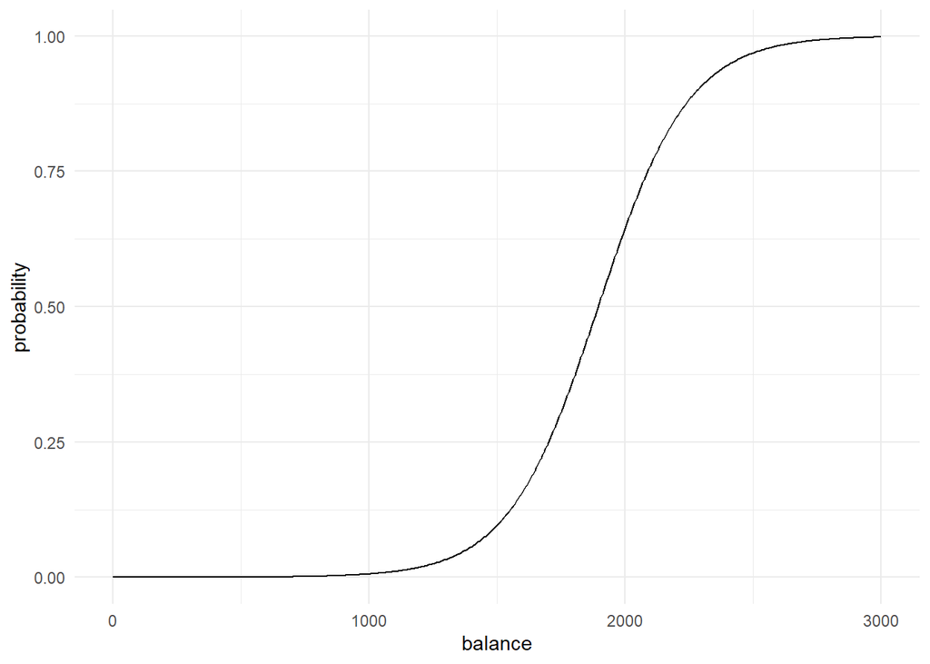

```r
balance_prob <- predict(lr_mod, newdata = balance_df, type = "response")

balance_df$probability <- balance_prob
balance_df %>% ggplot(aes(x = balance, y = probability)) +
  geom_line() +
  theme_minimal()
```

### Exercise 14

The 5-nn model had correctly classified 1931 observations in the test set. From the confusion matrix of the logistic regression model, we see that 1948 observations were correctly classified. Hence, we conclude that logistic regression indeed performs better than 5-nn.

```r
table(true = default_test$default, pred = default_test$prediction)
```

```
##      pred
## true    No  Yes
##   No  1925    5
##   Yes   47   23
```

### Exercise 15

```r
lda_mod <- lda(default ~ ., data = default_train)
```

### Exercise 16

The prior probabilities are estimated by the data proportions. Hence, we see that 3.3% of the people in the data set are default on loan. We can also see that people that are default on loan tend to have a higher balance (since its mean is higher), but do not neccessarily have a higher income (as the mean is close to each other).

```r
lda_mod
```

```
## Call:
## lda(default ~ ., data = default_train)
##
## Prior probabilities of groups:
##       No      Yes
## 0.967125 0.032875
##
## Group means:
##      student1   balance   income
## No  0.2888717  803.4652 33665.79
## Yes 0.3726236 1749.3143 32559.39
##
## Coefficients of linear discriminants:
##                    LD1
## student1 -1.452216e-01
## balance   2.231857e-03
## income    5.306987e-06
```

### Exercise 17

The LDA model classifies 1940 observations correctly. Therefore, it performs better than knn but worse than logistic regression.

```r
lda_preds <- predict(lda_mod, newdata = default_test)
table(true = default_test$default, predicted = lda_preds$class)
```

```
##      predicted
## true    No  Yes
##   No  1926    4
##   Yes   56   14
```

### Exercise 18

I have trained both the logistic regression and LDA models. The estimated coefficients are shown below.

```r
titanic_data <- read_csv("Titanic.csv") %>%
  mutate(PClass = factor(PClass),
         Sex = factor(Sex),
         Survived = factor(Survived)) %>%
  dplyr::select(-Name)
head(titanic_data)
```

| PClass | Age | Sex | Survived |
| --- | --- | --- | --- |
| 1st | 29.00 | female | 1 |
| 1st | 2.00 | female | 0 |
| 1st | 30.00 | male | 0 |
| 1st | 25.00 | female | 0 |
| 1st | 0.92 | male | 1 |
| 1st | 47.00 | male | 1 |

```r
titanic_lr <- glm(Survived ~ ., data = titanic_data, family = binomial)
titanic_lr
```

```
##
## Call:  glm(formula = Survived ~ ., family = binomial, data = titanic_data)
##
## Coefficients:
## (Intercept)    PClass2nd    PClass3rd          Age      Sexmale
##     3.75966     -1.29196     -2.52142     -0.03918     -2.63136
##
## Degrees of Freedom: 755 Total (i.e. Null);  751 Residual
##   (557 observations deleted due to missingness)
## Null Deviance:       1026
## Residual Deviance: 695.1     AIC: 705.1
```

```r
titanic_lda <- lda(Survived ~ ., data = titanic_data)
titanic_lda
```

```
## Call:
## lda(Survived ~ ., data = titanic_data)
##
## Prior probabilities of groups:
##         0         1
## 0.5859788 0.4140212
##
## Group means:
##   PClass2nd PClass3rd      Age   Sexmale
## 0 0.2618510 0.5417607 31.13167 0.8397291
## 1 0.3067093 0.2492013 29.35958 0.3067093
##
## Coefficients of linear discriminants:
##                   LD1
## PClass2nd -0.86491867
## PClass3rd -1.64009415
## Age       -0.02503764
## Sexmale   -2.09033385
```

Now we can predict the probability of survival in the case of the boy. We have

- Probability of survival in *logistic Regression* equal to 0.125;
- Probability of survival in *Linear Discriminant Analysis* equal to 0.09.

Hence, in both models the boy would probably not have survived.

```r
test1 <- data.frame(PClass = "3rd", Age = 14, Sex = "male")

predict(titanic_lr, newdata = test1, type = "response")
```

```
##         1
## 0.1254734
```

```r
predict(titanic_lda, newdata = test1, type = "response")
```

```
## $class
## [1] 0
## Levels: 0 1
##
## $posterior
##           0          1
## 1 0.9102243 0.08977569
##
## $x
##         LD1
## 1 -1.093421
```

In the case of the girl, we have

- Probability of survival in *logistic Regression* equal to 0.872;
- Probability of survival in *Linear Discriminant Analysis* equal to 0.906.

Hence, in both models the girl would probably have survived.

```r
test2 <- data.frame(PClass = "2nd", Age = 14, Sex = "female")

predict(titanic_lr, newdata = test2, type = "response")
```

```
##         1
## 0.8720519
```

```r
predict(titanic_lda, newdata = test2, type = "response")
```

```
## $class
## [1] 1
## Levels: 0 1
##
## $posterior
##            0         1
## 1 0.09387206 0.9061279
##
## $x
##        LD1
## 1 1.772089
```